# STAT 420: Homework 7

Fall 2016, Unger

Due: Tuesdsay, November 1 by 11:50 PM CT

# Assignment

## Exercise 1 (Nutrition Data revisited)

For this exercise we will use the data stored in `nutrition.csv` previously seen in HW04. It contains the nutritional values per serving size for a large variety of foods as calculated by the USDA. It is a cleaned version totaling 5,138 observations and is current as of September 2015.

The variables in the dataset are:

- `ID`
- `Desc` - Short description of food
- `Water` - in grams
- `Calories`
- `Protein` - in grams
- `Fat` - in grams
- `Carbs` - Carbohydrates, in grams
- `Fiber` - in grams
- `Sugar` - in grams
- `Calcium` - in milligrams
- `Potassium` - in milligrams
- `Sodium` - in milligrams
- `VitaminC` - Vitamin C, in milligrams
- `Chol` - Cholesterol, in milligrams
- `Portion` - Description of standard serving size used in analysis

**(a)** Fit the following multiple linear regression model in `R`. Use `Calories` as the response and `Carbs`, `Fat`, and `Protein` as predictors.

$$Y_i = \beta_0 + \beta_1 x_{i1} + \beta_2 x_{i2} + \beta_3 x_{i3} + \epsilon_i.$$

Here,

- $Y_i$ is `Calories`
- $x_{i1}$ is `Carbs`
- $x_{i2}$ is `Fat`
- $x_{i3}$ is `Protein`.

Use an $F$-test to test the significance of the regression. This is a repeat of a previous exercise, but is here again only as a reminder. This time report only the following:

- The p-value of the test.
- A statistical decision at $\alpha = 0.01$.
- A conclusion in the context of the problem.

When reporting these, you should explicitly state them in your document, not assume that a reader will find and interpret them from a large block of `R` output.

```r
nutrition <- read.csv("~/Desktop/nutrition.csv", comment.char="#")

nut_model = lm(Calories ~ Carbs + Fat + Protein, data = nutrition)
anova(nut_model)
```

```
## Analysis of Variance Table
##
## Response: Calories
##             Df    Sum Sq   Mean Sq F value    Pr(>F)
## Carbs        1  34486467  34486467   96634 < 2.2e-16 ***
## Fat          1 120595145 120595145  337918 < 2.2e-16 ***
## Protein      1   8130488   8130488   22782 < 2.2e-16 ***
## Residuals 5134   1832206       357
## ---
## Signif. codes:  0 '***' 0.001 '**' 0.01 '*' 0.05 '.' 0.1 ' ' 1
```

```r
summary(nut_model)
```

```
##
## Call:
## lm(formula = Calories ~ Carbs + Fat + Protein, data = nutrition)
##
## Residuals:
##     Min      1Q  Median      3Q     Max
## -381.13   -3.46   -0.31    5.33  259.23
##
## Coefficients:
##             Estimate Std. Error t value Pr(>|t|)
## (Intercept) 3.768066   0.492386   7.653 2.34e-14 ***
## Carbs       3.773605   0.009698 389.093  < 2e-16 ***
## Fat         8.804109   0.015305 575.248  < 2e-16 ***
## Protein     3.967269   0.026284 150.938  < 2e-16 ***
## ---
## Signif. codes:  0 '***' 0.001 '**' 0.01 '*' 0.05 '.' 0.1 ' ' 1
##
## Residual standard error: 18.89 on 5134 degrees of freedom
## Multiple R-squared:  0.9889, Adjusted R-squared:  0.9889
## F-statistic: 1.524e+05 on 3 and 5134 DF,  p-value: < 2.2e-16
```

```r
#The p-value of the test is 2.2e-16 so we can that it is very small. Since the p-value is smaller than alpha, we reject the null hypothesis.
#The regression is significant so therefore we see a useful linear relationship between the response and predictors. There is a linear relationship between Calories and at least some of Cars, Fat and Protein.
```

**(b)** Check the constant variance assumption for this model. Do you feel it has been violated? Justify your answer.

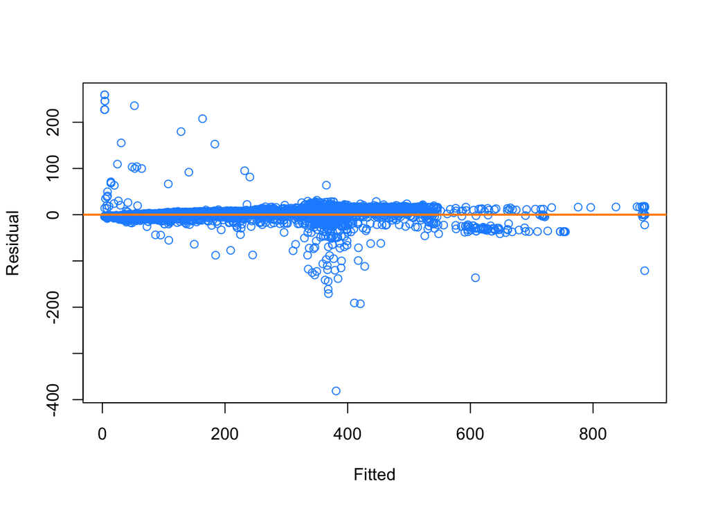

```r
#We know that the constant variance assumption is valid if at every fitted value the spread of the residuals is the same.

plot(fitted(nut_model), resid(nut_model), col = "dodgerblue", xlab = "Fitted", ylab = "Residual")
abline(h = 0, col = "darkorange", lwd = 2)
```

```r
#The constant variance assumption is violated as you notice the spread differentiation in the middle and start of the fitted values. The spread is not constant.
```

**(c)** Check the normality assumption for this model. Do you feel it has been violated? Justify your answer.

The `shapiro.test` function only allows for a maximum of 5000 data values. You may select a random sample of 5000 of your residuals instead of the full set. Use the following code and the seed given before running the Shapiro-Wilk test in `R`.

```r
set.seed(110116)
resid5000 = sample(resid(nut_model), 5000)
shapiro.test(resid5000)
```

```
##
##  Shapiro-Wilk normality test
##
## data:  resid5000
## W = 0.51722, p-value < 2.2e-16
```

```r
#The null hypothesis assumes the data follow a normal distribution, thus the small p-value indicates we believe there is only a small probability the data follow a normal distribution. The small p-value allows us to reject the null and conclude that the normality assumption does not hold.
```

**(d)** Check for any high leverage observations. Report the number of observations you determine to have high leverage. Print only the first five.

```r
calories_lev = lm(Calories~Carbs+Fat+Protein, data = nutrition)
high_lev = hatvalues(calories_lev) > 2 * mean(hatvalues(calories_lev))
length(hatvalues(calories_lev)[high_lev])
```

```
## [1] 257
```

```r
#First 5
hatvalues(nut_model)[high_lev][1]
```

```
##           4
## 0.002647218
```

```r
hatvalues(nut_model)[high_lev][2]
```

```
##           6
## 0.003469126
```

```r
hatvalues(nut_model)[high_lev][3]
```

```
##          18
## 0.004180836
```

```r
hatvalues(nut_model)[high_lev][4]
```

```
##          61
## 0.005307021
```

```r
hatvalues(nut_model)[high_lev][5]
```

```
##          62
## 0.005724268
```

**(e)** Check for any influential observations. Report the number of observations you determine to be influential. Print only the first five.

```r
inf = cooks.distance(calories_lev) > 4 / length(cooks.distance(calories_lev))
length(cooks.distance(calories_lev)[inf])
```

```
## [1] 187
```

```r
#First 5
cooks.distance(calories_lev)[inf][1]
```

```
##          18
## 0.001607581
```

```r
cooks.distance(calories_lev)[inf][2]
```

```
##         115
## 0.001012392
```

```r
cooks.distance(calories_lev)[inf][3]
```

```
##         255
## 0.001305357
```

```r
cooks.distance(calories_lev)[inf][4]
```

```
##        301
## 0.00126538
```

```r
cooks.distance(calories_lev)[inf][5]
```

```
##         302
## 0.001305357
```

**(f)** Refit the additive multiple regression model without any points you identified as influential. Compare the coefficients of this fitted model to the previously fitted model.

```r
ca_model = lm(Calories~Carbs+Fat+Protein, data = nutrition, subset = cooks.distance(calories_lev) <= 4 / length(cooks.distance(calories_lev)))
coef(ca_model)
```

```
## (Intercept)       Carbs         Fat     Protein
##  -0.5211544   3.8731857   8.8909580   4.1670504
```